# Praca domowa 2

## Dane

Dane wykorzystane w Pracy domowej 2 opisują wycenę nieruchmości. Każda obserwacja jest pewną nieruchmością, która posiada informacje takie jak powierzchnia, liczba pokoi, liczba łazienek i wiele więcj. Opis wszystkich kolumn w pliku `README.md`.

## Zadanie 1

Jak wygląda rozkład ceny nieruchomości w poszczególnych kodach pocztowych na przestrzeni lat? Rozważamy kody pocztowe, które mają więcej niż 280 posiadłości.

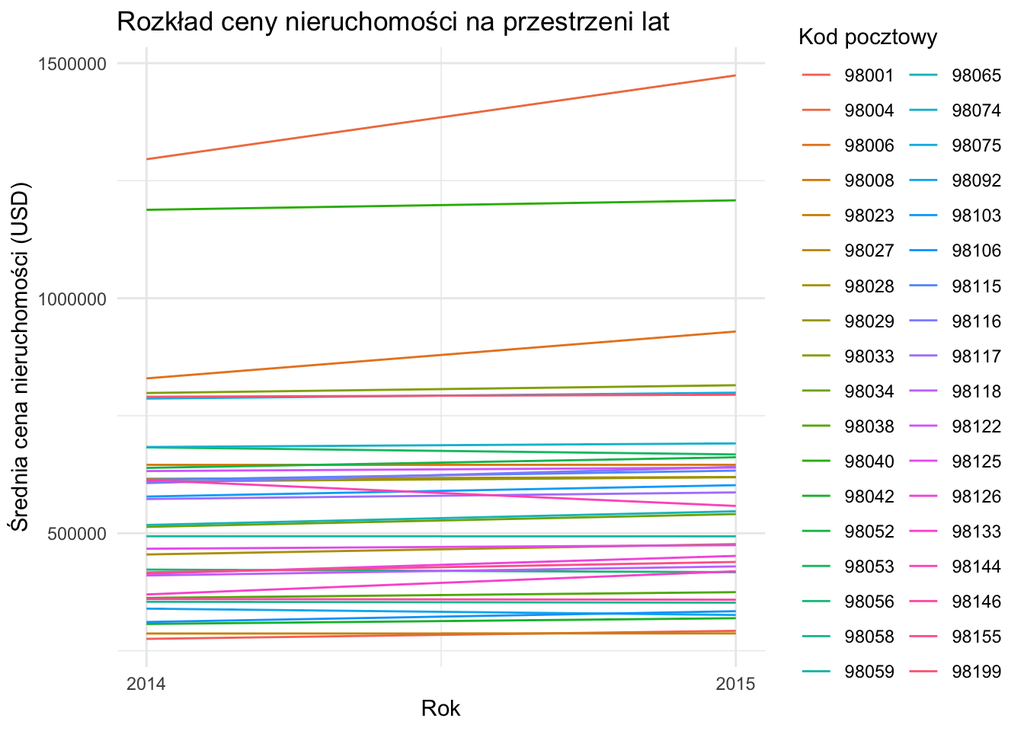

```r
valid <- df %>%
  count(zipcode) %>%
  filter(n > 280) %>%
  pull(zipcode)

df_1 <- df %>%
  filter(zipcode %in% valid) %>%
  mutate(date = as.Date(date, format = "%Y%m%dT%H%M%S")) %>%
  mutate(year = format(date, "%Y")) %>%
  group_by(zipcode, year) %>%
  summarise(avg_price = mean(price, na.rm = TRUE))

ggplot(df_1, aes(x = as.numeric(year), y = avg_price, color = factor(zipcode))) +
  geom_line() + labs(
    title = "Rozkład ceny nieruchomości na przestrzeni lat",
    x = "Rok",
    y = "Średnia cena nieruchomości (USD)",
    color = "Kod pocztowy") +
  scale_x_continuous(breaks = seq(min(as.numeric(df_1$year)), max(as.numeric(df_1$year)), by = 1)) +
  theme_minimal()
```

**Komentarz: wykres pokazuje ogólną tendencję wzrostową cen nieruchomości o różnych kodach pocztowych, ale z wyraźnymi różnicami zarówno pod względem poziomu cen, jak i tempa wzrostu w poszczególnych rejonach (kodach pocztowych).**

## Zadanie 2

Czy jest różnica w rozkładzie ceny nierchomości od powierzchni mieszkalnej uwzględniając podział na nieruchomości z piwnicą i bez?

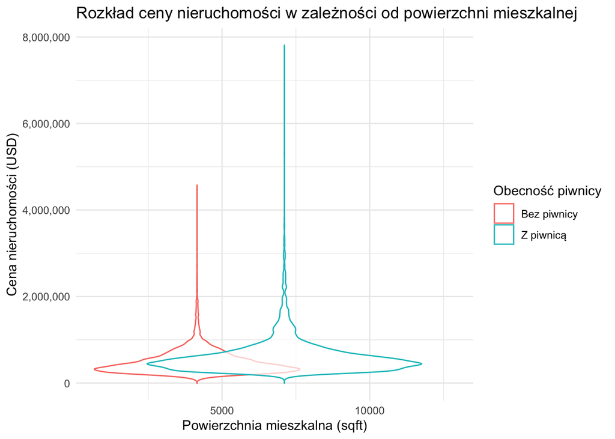

```r
df_2 <- df %>%
  mutate(has_basement = ifelse(sqft_basement > 0, "Z piwnicą", "Bez piwnicy"))

ggplot(df_2, aes(x = sqft_living, y = price, color = has_basement)) +
  geom_violin(trim = FALSE, alpha = 0.7) + labs(
    title = "Rozkład ceny nieruchomości w zależności od powierzchni mieszkalnej",
    x = "Powierzchnia mieszkalna (sqft)",
    y = "Cena nieruchomości (USD)",
    color = "Obecność piwnicy") +
  scale_y_continuous(labels = function(x) format(x, big.mark = ",", scientific = FALSE)) +
  theme_minimal()
```

## Zadanie 3

Jaka jest zależność pomiędzy jakością wykończenia nieruchomości a liczbą pięter?

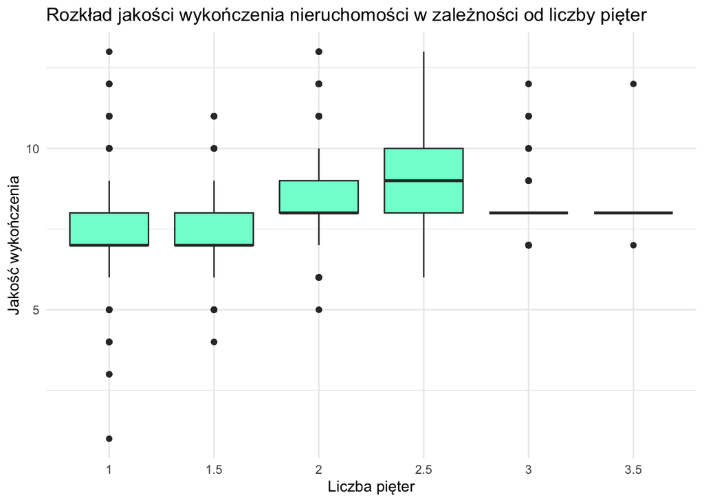

```r
ggplot(df, aes(x = factor(floors), y = grade)) +
  geom_boxplot(fill = "aquamarine") + labs(
    title = "Rozkład jakości wykończenia nieruchomości w zależności od liczby pięter",
    x = "Liczba pięter",
    y = "Jakość wykończenia") +
  theme_minimal()
```

**Komentarz: wykres sugeruje, że jakość wykończenia nieruchomości jest najwyższa dla budynków o 2-3 piętrach, a budynki o większej liczbie pięter są bardziej jednolite pod względem jakości.**

## Zadanie 4

Jaka jest zależność między powierzchnią mieszkalną nieruchomości a powierzchnią gruntu w podziale na liczbę sypialni?

[figure not shown]

```r
df_4 <- df %>%
  mutate(bedrooms = case_when(
    bedrooms < 6 ~ as.character(bedrooms), TRUE ~ "6+"))

ggplot(df_4, aes(x = sqft_living, y = sqft_lot, color = factor(bedrooms))) +
  geom_point(alpha = 0.2) +
  labs(
    title = "Zależność między powierzchnią mieszkalną a powierzchnią gruntu",
    x = "Powierzchnia gruntu (sqft)",
    y = "Powierzchnia mieszkalna (sqft)",
    color = "Liczba sypialni"
  ) +

  theme_minimal()
```

## Zadanie 5

Rozważmy tylko nieruchomości, które miały remont. W której dekadzie było najwięcej przeprowadzonych remontów? Czy w poszczególnych dekadach jest porównywalny procent nieruchmości dla każdej wartości miary jakości i wykończenia nieruchomości?

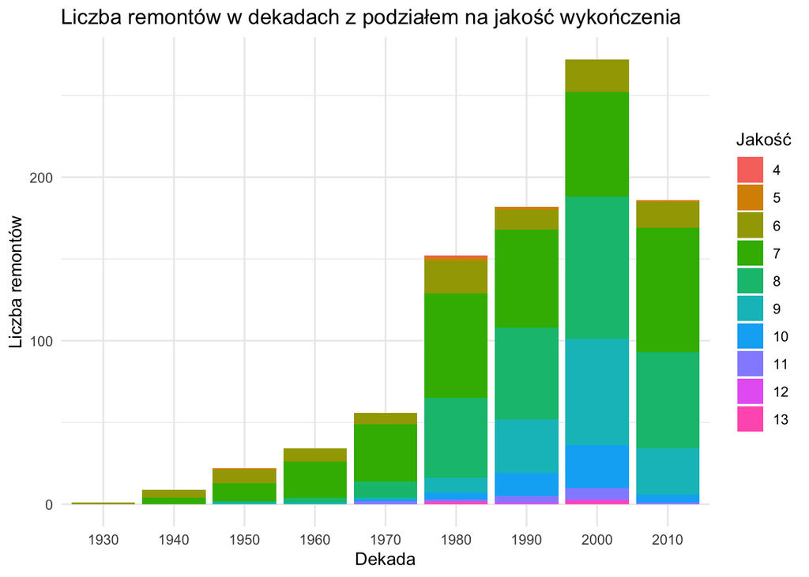

```r
df_5 <- df %>%
  filter(yr_renovated > 0) %>%
  mutate(decade = floor(yr_renovated / 10) * 10) %>%
  group_by(decade, grade) %>%
  summarise(renovations_count = n())

ggplot(df_5, aes(x = factor(decade), y = renovations_count, fill = factor(grade))) +
  geom_bar(stat = "identity") + labs(
    title = "Liczba remontów w dekadach z podziałem na jakość wykończenia",
    x = "Dekada",
    y = "Liczba remontów",
    fill = "Jakość") +
  theme_minimal()
```

## Zadanie 6

Jak prezentuje się wartość minimalna, średnia i maksymalna ceny nieruchmości w podziele na rok budowy nieruchomości.

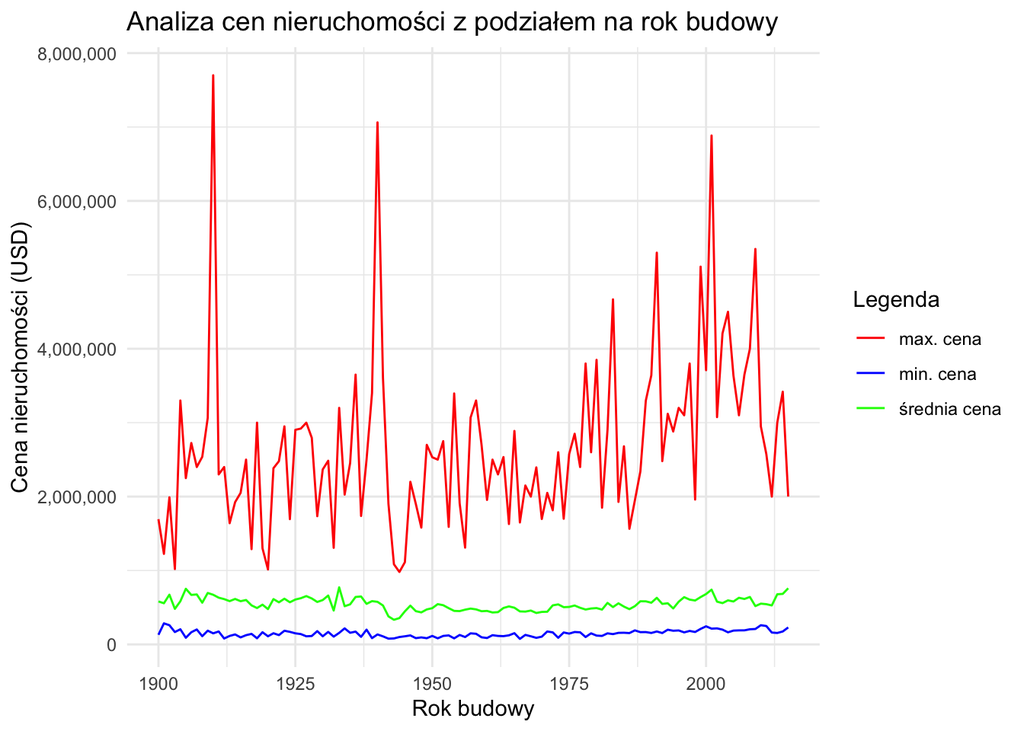

```r
df_6 <- df %>%
  group_by(yr_built) %>%
  summarize(min = min(price), max = max(price), avg = mean(price))

ggplot(df_6, aes(x = yr_built)) +
  geom_line(aes(y = min, color = "min. cena")) +
  geom_line(aes(y = avg, color = "średnia cena")) +
  geom_line(aes(y = max, color = "max. cena")) + labs(
    title = "Analiza cen nieruchomości z podziałem na rok budowy",
    x = "Rok budowy",
    y = "Cena nieruchomości (USD)",
    color = "Legenda") +
  theme_minimal() +
  scale_y_continuous(labels = function(x) format(x, big.mark = ",", scientific = FALSE)) +
  scale_color_manual(values = c("min. cena" = "blue", "średnia cena" = "green", "max. cena" = "red"))
```

**Komentarz: wykres pokazuję, jak nieprzewidywalne są ceny maksymalne nieruchomości, podczas gdy ceny średnie i minimalne są stabline i podobne na przestrzeni lat. Również wartość średnia cen nieruchomoścu jest dużo bliższa do ceny minimalnej niż maksymalnej.**